# Lecture 5: Planning Digital Marketing Campaigns

SKOC42: Digital Marketing Communication 2026

nils.holmberg@iko.lu.se

## Marketing Campaign Cases

- Case 1: [Polestar](https://www.polestar.com)
- Case 2: [Ramlösa](https://ramlosa.se/produkter)
- Case 3: [The Royal Swedish Opera](https://www.operan.se/en/)
- Case 4: [Visit Malmö](https://www.visitmalmo.se/en/)
- `1 campaign = 1 main objective, KPI`
- `2 channels (ad platform + landing page)`

[figure not shown]

## SOSTAC 01:

**Situation**

## Situation: Auditing Customer Experience

- `Situation: Map Opera journeys: where 18–24s drop out`
- Audit Polestar findability vs. Tesla in search
- Content audit: Ramlösa as soda vs. natural
- Benchmark Visit Malmö’s OVP regionally
- Usability review of Opera mobile booking

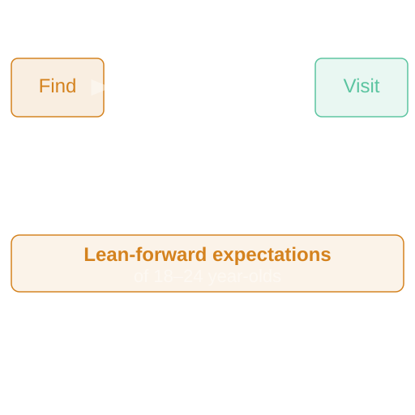

## Situation: Analyzing Campaign Insights

- `Insight: Market intel: what entertainment wins youth`
- Referrer mix: food blogs → Visit Malmö
- Brand search volume for “Polestar”
- Keyword gap on “natural summer drink”
- Social listening for “cool vibe” mentions

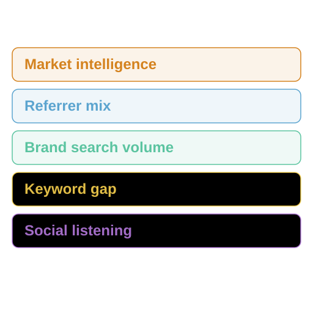

## Situation: Performance Benchmarking

- `Benchmark: CTR for Polestar ads vs. Tesla baselines`
- CVR on Opera children’s & youth pages
- CPA for new Ramlösa health-conscious leads
- Tesla competitor benchmarking
- Attraction efficiency for Malmö summer

[figure not shown]

## Situation: Micro-environment Players

- `Ecosystem: Online influencers for Polestar mobility`
- Festival aggregators for Visit Malmö
- Parent-forum mentions of Opera kids’ shows
- Affiliate partners for Ramlösa wellness
- UGC from young Opera-goers as social proof

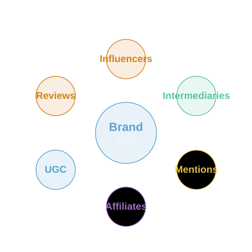

## Situation: Information Processing

- `Fennis: Preattentive cues grab non-conscious attention`
- Truth effect: simple, repeated “natural” claim
- Hierarchy-of-effects: AIDA vs. youth behaviour
- Clutter: Tesla holds dominant mental share
- Comprehension: Opera as boring vs. exciting

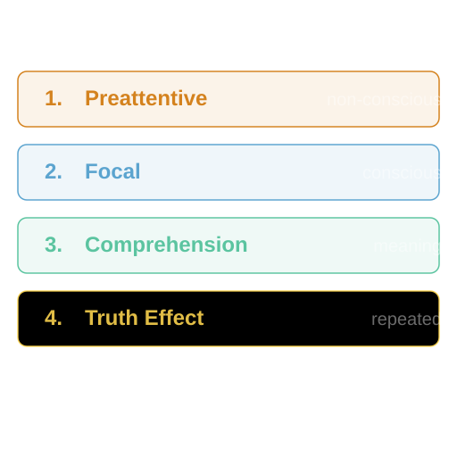

## SOSTAC 02:

**Objectives**

## Objectives: SMART Campaign Goals

- `SMART: Conversion rate lift for Opera mobile bookings`
- 10% share of search for “electric performance”
- Online revenue % from Malmö summer packages
- Email list quality of health-conscious leads
- Brand awareness milestones for urban 18–24s

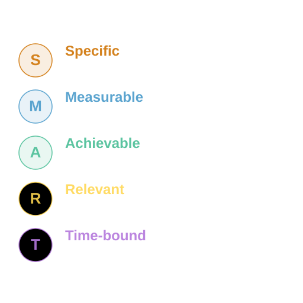

## Objectives: RACE Framework

- `Funnel: Reach: 50k visitors to "Summer Cafés" guide`
- Act: 15% quiz rate on “Which Opera Are You?”
- Convert: 1,000 Ramlösa trial purchases
- Engage: foster Opera advocacy and reviews
- Track stage-by-stage drop-out

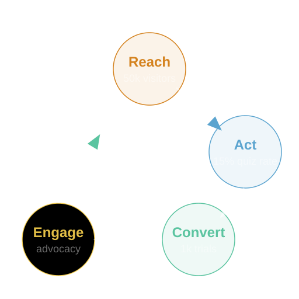

## Objectives: VQVC Metrics

- `Targets: Volume: 100k monthly Polestar impressions`
- Quality: bounce < 30% on festival pages
- Value: high AOV for premium Opera packages
- Cost: allowable CPA for mobility leads
- Lifetime value of trial → subscription

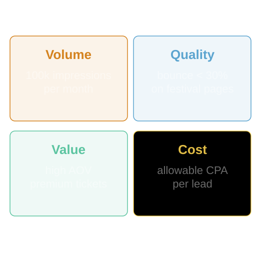

## Objectives: Conversion and Interaction

- `Pathway: Conversion model for Opera children's missions`
- Lead-gen via “Behind the Scenes” sign-ups
- Interactive itinerary selector for Malmö
- 20% of Polestar visitors → email opt-in
- Forecast off-line attendance from web visits

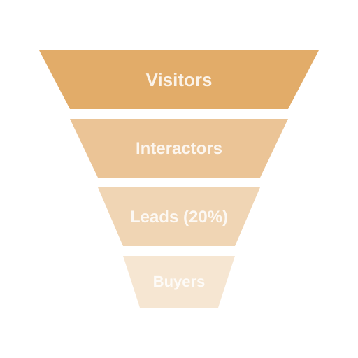

## Objectives: Brand & Perception Metrics

- `Brand: Familiarity lift for Polestar among 35–45s`
- Sentiment shift: Ramlösa soda → natural
- Top-of-mind awareness for Visit Malmö
- Polestar brand preference vs. Tesla
- NPS among the Opera’s young visitors

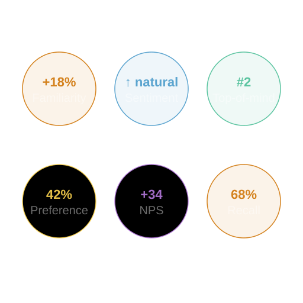

## SOSTAC 03:

**Strategy**

## Strategy: Segmentation & Targeting

- `STP: Urban 35–45s with high income for Polestar`
- Active, health-conscious for Ramlösa
- 18–24s at city events for the Opera
- Psychographic targeting for Malmö visitors
- Tactical online segmentation by search intent

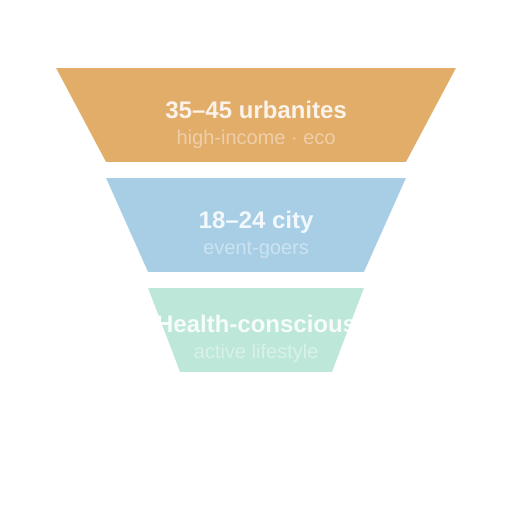

## Strategy: Online Value Proposition

- `OVP: Polestar: "better option than Tesla"`
- Ramlösa: “natural and refreshing”
- Opera: “exciting performance” for youth
- Malmö: cosmopolitan vibe with old-world charm
- OVP front-and-centre on landing pages

[figure not shown]

## Strategy: Communications Mix

- `Mix: Balance brand-building with direct response`
- Inbound search for health-conscious leads
- Paid + owned + earned for Malmö vibe
- Push (display) + pull (search) for Opera
- Content distribution via influencer outreach

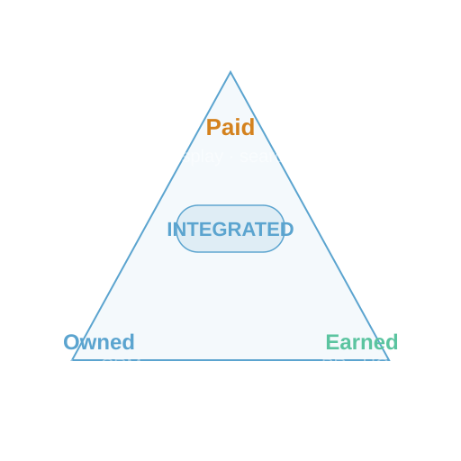

## Strategy: Timing & Integration

- `Cadence: Summer-specific Ramlösa flavour bursts`
- Festival burst + always-on social for Malmö
- Omnichannel ties tickets to city events
- Event-triggered emails after Opera visits
- Coordinate across phone, tablet, desktop

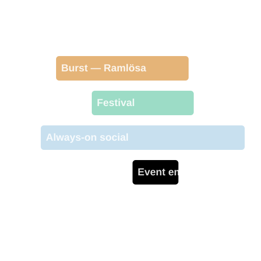

## Strategy: Content Marketing

- `Content: Hero design videos map to Reach (Polestar)`
- Content matrix audits Malmö’s assets
- ToFu blogs on “Classical Masterpieces”
- Ramlösa roadmap of essential vs. targeted
- Editorial calendar for sustainable stories

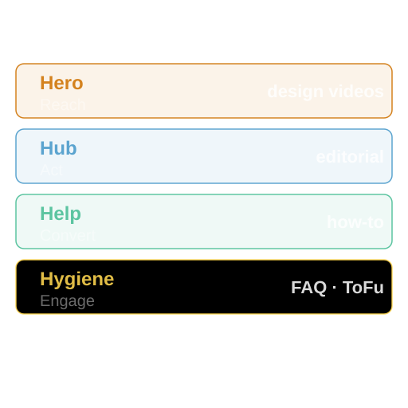

## Strategy: Persuasion Principles

- `Fennis: Alpha: emphasise Polestar's amazing design`
- Omega: reduce Ramlösa’s soda reluctance
- Dual-process: detailed args for high-income
- Humour + affect for the Opera’s youth
- Pioneering advantage: Ramlösa since 1707

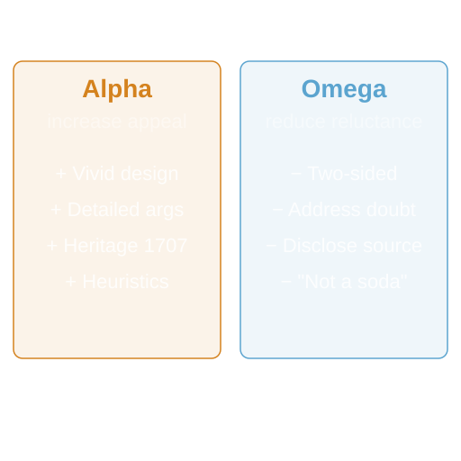

## SOSTAC 04:

**Tactics**

## Tactics: Search Engine Marketing

- `Search: On-page for "innovative electric car" (Polestar)`
- Paid search around city festivals (Opera)
- Ramlösa keyword list for “natural refreshment”
- Navigational search audit for ticket portals
- Backlink analysis of sustainable lifestyle blogs

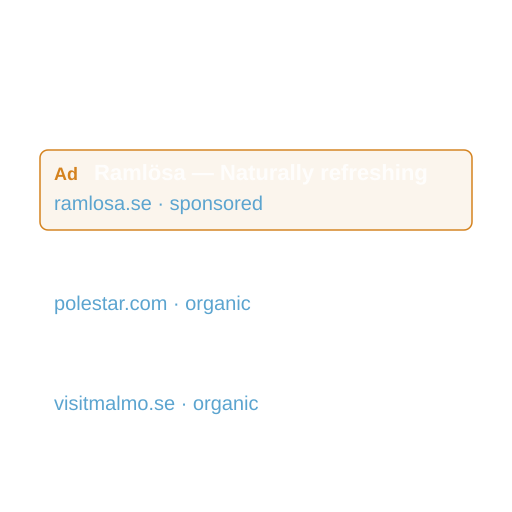

## Tactics: Social Media Marketing

- `Social: Amplification of Malmö's "cool vibe" shares`
- Social CRM for the Opera’s ballet fans
- TikTok hashtag challenges for Ramlösa
- Daily Polestar mobility tips, organically
- Social log-on simplifies Opera registration

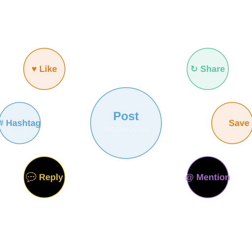

## Tactics: Email & Mobile Messaging

- `Direct: Welcome sequence highlights Ramlösa heritage`
- Push notifications for last-minute Opera deals
- Opt-in innovation newsletter for Polestar
- Dynamic content by active/health preference
- CRITICAL checklist applied to Opera youth emails

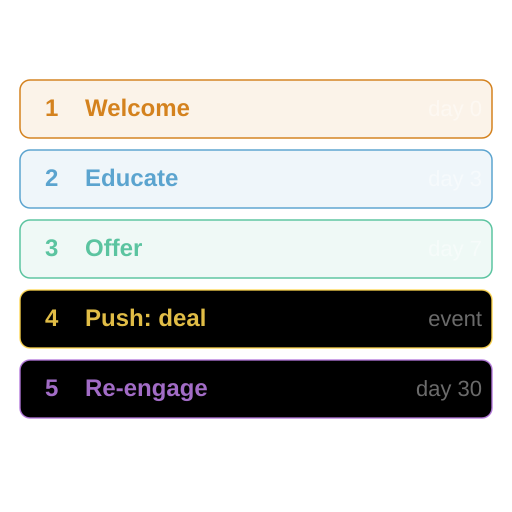

## Tactics: Digital PR & Influencers

- `PR: Urban bloggers position Polestar vs. Tesla`
- Travel + food press mentions for Malmö
- Parent & lifestyle bloggers for Ramlösa
- Opera reputation monitoring on social
- Guest blogging on youth cultural sites

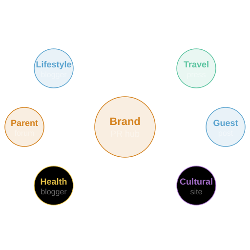

## Tactics: Display & Video Advertising

- `Display: Programmatic targeting of urban high-income`
- Behavioural retargeting for Opera ad viewers
- YouTube video showcasing Polestar’s design
- Rich-media banners for Malmö’s festivals
- Native ads in health & wellness editorial

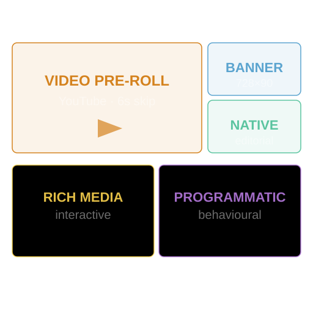

## SOSTAC 05:

**Actions**

## Actions: Timeline & Execution

- `Plan: Polestar launch Gantt, back from live date`
- Festival waves integrate social, email, display
- Opera editorial calendar before ticket launch
- Ramlösa media schedule peaks in summer
- Project initiation secures budget and sponsors

[figure not shown]

## Actions: Site & App Development

- `Build: Agile prototypes Opera youth features fast`
- Scrum for Polestar’s complex buying unit
- User-testing with 18–24s refines booking
- Festival microsite content for Malmö
- Site designers transfer Polestar’s design DNA

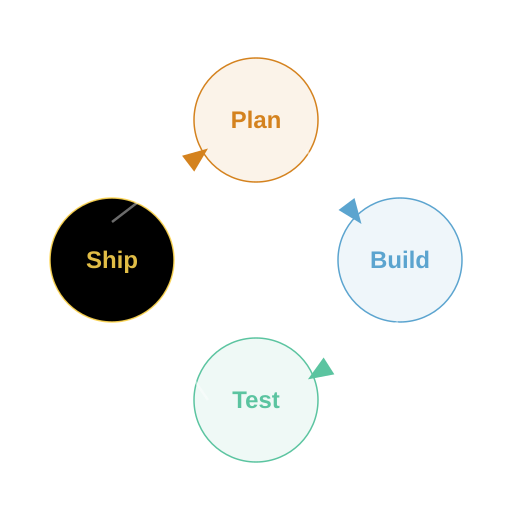

## Actions: Resource Allocation

- `Roles: Outsource Polestar strategy/design/promo`
- Site owner coordinates Malmö’s providers
- Opera UX analyst optimises youth conversion
- Polestar webmaster maintains availability
- Ramlösa stakeholders: marketing + product

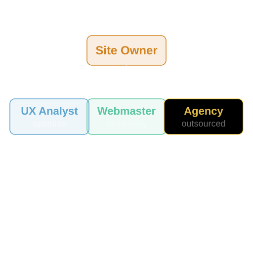

## Actions: Implementation Intentions

- `Fennis: If event arises → then book Opera ticket`
- Cues to action: cold bottle on hot day
- Polestar copy forms a showroom-visit plan
- Vivid Opera stories aid mental simulation
- Link Polestar to charging/commute context

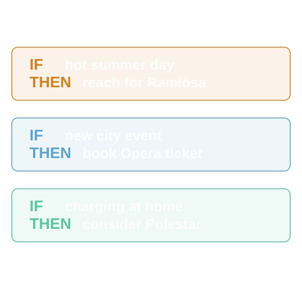

## SOSTAC 06:

**Control**

## Control: Dashboards & KPIs

- `Dashboard: Polestar dashboard tracks Tesla-comparison KPIs`
- Performance system checks Ramlösa perception
- Malmö’s WebInsights covers summer contribution
- Leading indicators flag Opera slow shows early
- Diagnose monthly variance in youth interaction

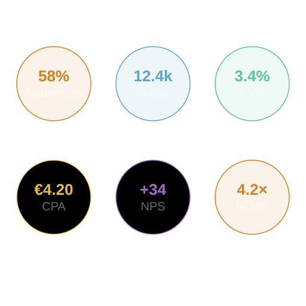

## Control: Analytics & Tracking

- `Analytics: GA finds qualified-lead keywords for Polestar`
- Customer journey: food blog → festival ticket
- Clickstream isolates Opera checkout drop-offs
- UTM splits LinkedIn vs. tech publisher ads
- Attrition tracking on Ramlösa trial sign-up

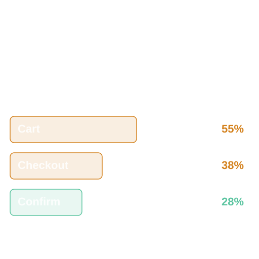

## Control: Testing & Optimisation

- `CRO: A/B test Opera headlines and visuals for youth`
- MVT for Malmö vibe imagery × CTAs
- CRO turns Polestar researchers into leads
- Split test Ramlösa rational vs. emotional
- Smart bidding refines PPC vs. Tesla CPA

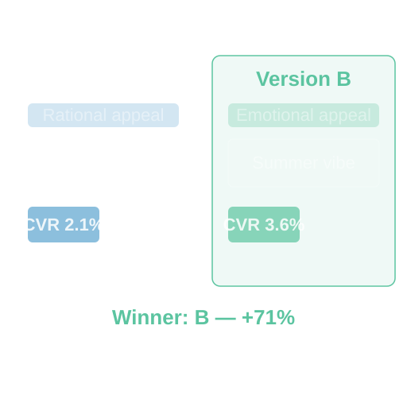

## Control: Voice of Customer

- `VoC: Intent-satisfaction surveys at Opera`
- Social listening on Polestar polarity
- Exit-intent surveys catch Opera leavers
- Qualitative Ramlösa perception feedback
- Crowdsource ideas to make Opera “exciting”

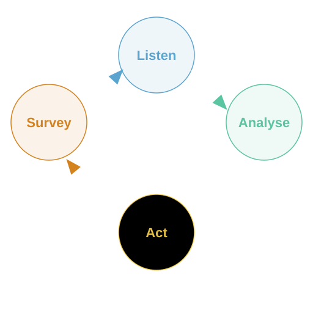

## Control: Social Influence

- `Fennis: Liking: youth testimonials lift Opera bookings`
- Social proof: stars improve Polestar ratings
- Scarcity: limited-time Opera youth offer
- Reciprocity: free Ramlösa samples at events
- Authority: innovation awards for Polestar

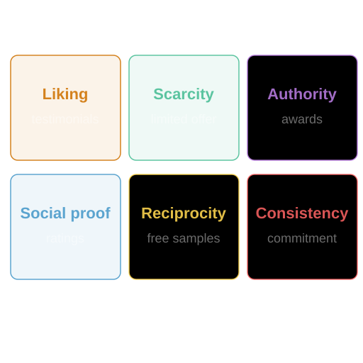